# Buffer Optimization

Bin Z. He, originally by Hanxi Tang

2023-12-18, updated 2024-09-17

```r
require(tidyverse)
require(flowCore)
require(flowClust)
require(openCyto)
require(ggcyto)
require(cowplot)
require(ggrdiges)
```

```r
old <- theme_set(theme_minimal())
```

# Background

We previously observed a “dead-like” population in mock-treated samples, and also an unstained population in 10 mM H2O2-treated cells. Here, we explore different staining buffer compositions and monitor those two behaviors.

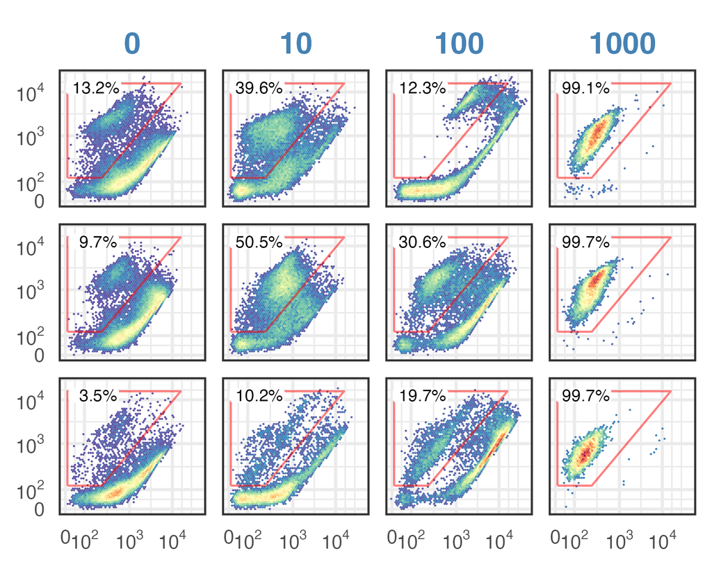

# Data

This is the flow cytometry data for mig-log phase *C. glabrata* cells stained with PI/SYTO9/PI+SYTO9 in different staining buffers, and run through flow cytometry (details in ELN).

## Import data

> FCS files are stored in RDSS/user/flow cytometry, FCS is read and write into an input tsv table. The tsv file is avaliable from the Input folder.

```r
# use relative path to make it easier for collaboration
data.path = "../../../00-Shared/02-data/02.01-flow-cytometry/20240108-extended-buffer-optimization/"
dat.f1e <- read.flowSet(path = data.path,
                        transformation = FALSE,        # the original values are already linearized.
                        emptyValue = FALSE,
                        alter.names = TRUE,            # change parameter names to R format
                        column.pattern = ".H|FSC|SSC") # only load the height variables for the fluorescent parameters
```

Simplify the sample names

|  | date | buffer | treatment | dye | name |
| --- | --- | --- | --- | --- | --- |
| 0108pb_0_b | 2024-01-08 | PBS | 0 | Both | 0108pb_0_b |
| 0108pb_0_p | 2024-01-08 | PBS | 0 | PI | 0108pb_0_p |
| 0108pb_0_s | 2024-01-08 | PBS | 0 | SYTO9 | 0108pb_0_s |
| 0108pb_10_b | 2024-01-08 | PBS | 10 | Both | 0108pb_10_b |
| 0108pb_10_p | 2024-01-08 | PBS | 10 | PI | 0108pb_10_p |
| 0108pb_10_s | 2024-01-08 | PBS | 10 | SYTO9 | 0108pb_10_s |
| 0108pb_100_b | 2024-01-08 | PBS | 100 | Both | 0108pb_100_b |
| 0108pb_100_p | 2024-01-08 | PBS | 100 | PI | 0108pb_100_p |
| 0108pb_100_s | 2024-01-08 | PBS | 100 | SYTO9 | 0108pb_100_s |
| 0108pb_1000_b | 2024-01-08 | PBS | 1000 | Both | 0108pb_1000_b |

[output cut: 134 more lines]

# Gatting strategies

> The following gaphing steps are used to gate singlets by FSC and SSC values. Only singlets are included in analysis.

## Gate for singlets

Gate for outlier

[output not shown]

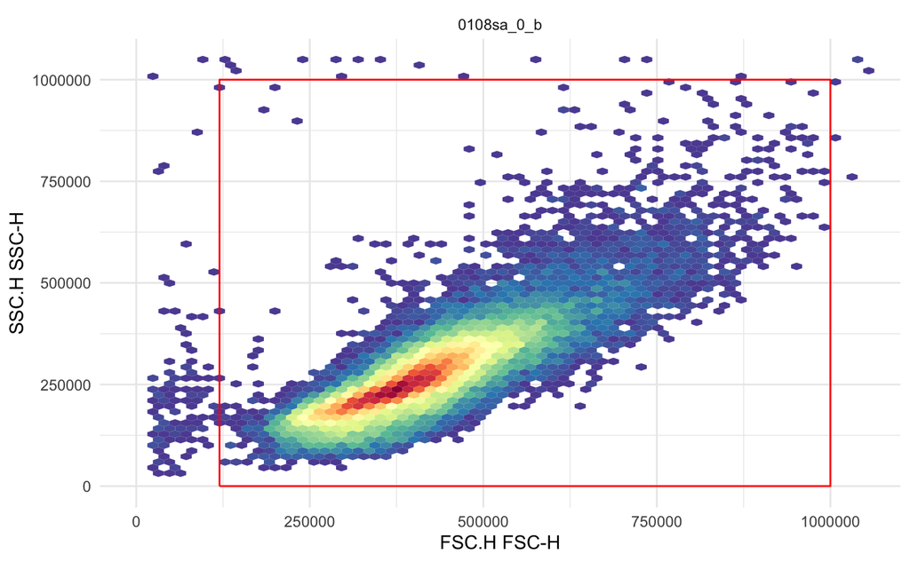

```r
outlier.gate <- rectangleGate(filterId = "-outlier", "FSC.H" = c(1.2e5, 1e6), "SSC.H" = c(1e2, 1e6))
ggcyto(dat[13], aes(x = FSC.H, y = SSC.H), subset = "root") +
  geom_hex(bins = 64) + geom_gate(outlier.gate) + facet_wrap(~name, ncol = 2) + ggcyto_par_set(limits = "instrument")
```

Add gate to GS

```r
recompute(gs)
```

```
done!
```

Gate for singlets

[output not shown]

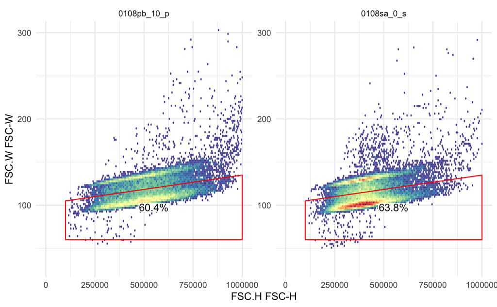

```r
scPars <- ggcyto_par_set(limits = list(x = c(0,1e6), y = c(30,300)))
ex <- Subset(dat[c(5, 15)], outlier.gate)
polygon <- matrix(c(1e5, 1e5, 1e6, 1e6,
                    60, 105, 135,60), ncol = 2)
colnames(polygon) <- c("FSC.H", "FSC.W")
singlet.gate <- polygonGate(filterId = "singlet", .gate = polygon)
ggcyto(ex, aes(x = FSC.H, y = FSC.W)) + geom_hex(bins = 128) + geom_gate(singlet.gate) + geom_stats() + scPars
```

Add this gate to the gatingSet

```r
gs_pop_add(gs, singlet.gate, parent = "-outlier", name = "singlet")
```

```
[1] 3
```

```r
recompute(gs)
```

```
done!
```

## Gate for the unstained population

> Unstained population is defined as population below 10^2 in both channels (in the noise range).

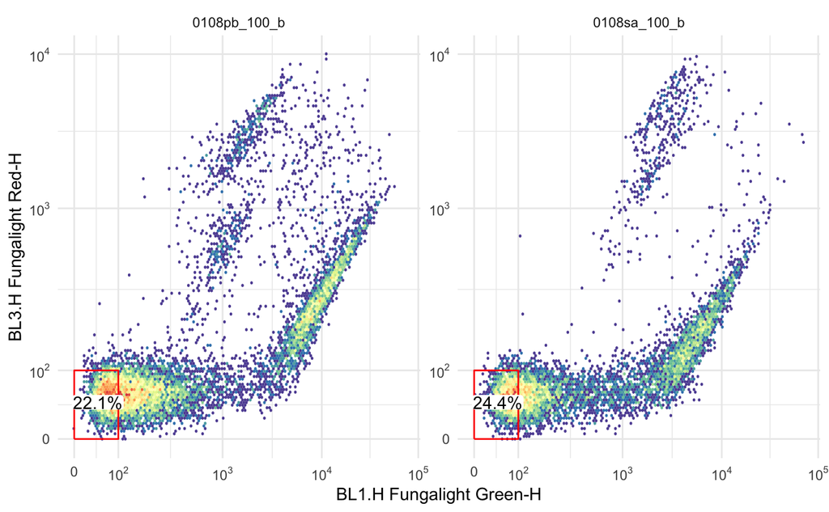

```r
#scPars <- ggcyto_par_set(limits = list(x = c(0,1e6), y = c(0,1e6)))
select <- c(7,19)
ex <- Subset(dat[select], singlet.gate)
polygon2 <- matrix(c(0, 1e2, 1e2, 0,
                    0, 0, 1e2, 1e2), ncol = 2)
colnames(polygon2) <- c("BL1.H", "BL3.H")
unstained.gate <- polygonGate(filterId = "unstained", .gate = polygon2)
ggcyto(ex, aes(x = BL1.H, y = BL3.H)) +
  geom_hex(bins = 128) +
  geom_gate(unstained.gate) + geom_stats() +# scPars +
  scale_x_logicle() + scale_y_logicle()
```

Add this gate to the gatingSet

## Gate for the dead-like population

> Dead population is defined based on 1M treated sample.

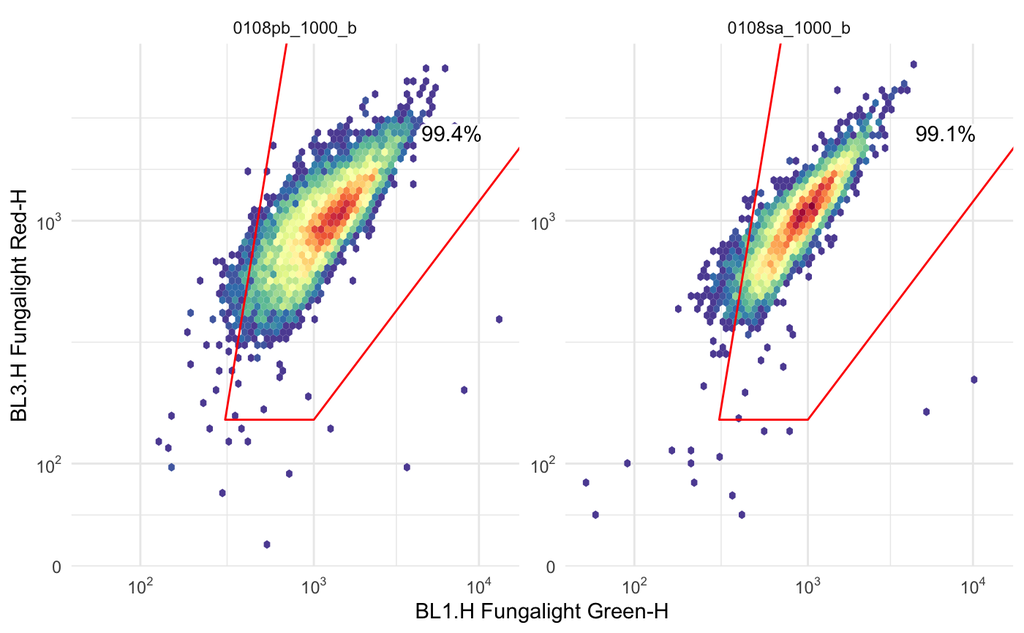

```r
#scPars <- ggcyto_par_set(limits = list(x = c(0,1e6), y = c(0,1e6)))
select <- c(10,22)
ex <- Subset(dat[select], singlet.gate)
polygon <- matrix(c(10^3, 10^2.5,10^3, 10^5,
                    10^4.5, 10^2.2, 10^2.2, 10^4), ncol = 2)
colnames(polygon) <- c("BL1.H", "BL3.H")
dead.gate <- polygonGate(filterId = "dead", .gate = polygon)
ggcyto(ex, aes(x = BL1.H, y = BL3.H)) +
  geom_hex(bins = 64) +
  geom_gate(dead.gate) + geom_stats() + #scPars +
  scale_x_logicle() + scale_y_logicle()
```

Add this gate to the gatingSet

> Exported gated event counts

```r
gated_stats_f1g <- gs_pop_get_stats(gs) %>%
  as_tibble() %>%
  mutate(pop = gsub(".*/", "", pop), pop = gsub("-outlier", "cells", pop)) %>%
  pivot_wider(names_from = pop, names_prefix = "n_", values_from = count)
gated_stats_f1g$percent_Dead <- gated_stats_f1g$n_dead / gated_stats_f1g$n_singlet
gated_stats_f1g$percent_Unstained <- gated_stats_f1g$n_unstained / gated_stats_f1g$n_singlet
gated_data <- cbind(pData(dat.f1e), gated_stats_f1g) %>%
    as.tibble() %>% relocate(name, .after = last_col())
#write_tsv(gated_data, file = "../Input/20240325-Ca-PI-Both-Distinguishing-Power-gated-ht.tsv")
print(gated_data)
```

[output not shown]

# Analysis & Plots

## Visualize one set of data

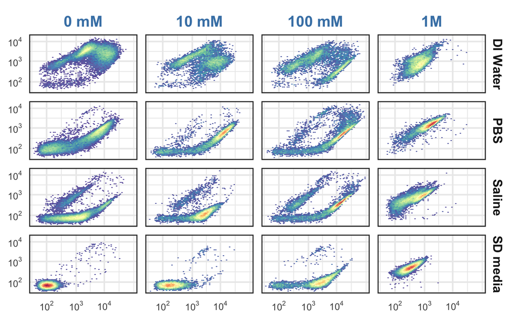

```r
subset.to.plot <- with(pData(gs), dye == "Both" & date == '2024-01-10')
p <- ggcyto(gs[subset.to.plot],
            aes(x = BL1.H, y = BL3.H), subset = "singlet") +
  geom_hex(aes(fill = after_stat(density)), bins = 64) +
  facet_grid(buffer ~ treatment,
             labeller = as_labeller(c(tr.levels, bu.levels), multi_line = F)) +
  scale_x_logicle(breaks = c(10^2, 10^3, 10^4)) +
  scale_y_logicle(breaks = c(10^2, 10^3, 10^4)) +
  theme_minimal(base_size = 16) +
  panel_border(color = "gray20") + #background_grid(major = "none", minor = "none") +
  theme(
    #axis.line = element_blank(),
    strip.text.y = element_text(face = 2),
    strip.text.x = element_text(size = rel(1.2), color = "steelblue", face = 2),
    axis.text = element_text(size = rel(0.6)),
    plot.title = element_blank(),
    legend.position = "none",
    axis.title = element_blank()
  )

p
```

> Several output graphs are produced, and are stored in the Output folder.

```r
sub <- dat.f1e[pData(dat.f1e)$Dye == "PI" & pData(dat.f1e)$Date == "010924"]
sg <- Subset(sub, singlet.gate)
p2 <- sg %>%
  ggcyto(aes(x = "BL1.H", y = "BL3.H")) +
  geom_hex(bins = 80, aes(fill = ..ncount..))  +
  facet_grid(Buffer ~ Treatment,
             labeller = as_labeller(c("0 mM" = "0 mM", "10 mM" = "10 mM", "100 mM" = "100 mM", "1000 mM" = "1000 mM",
                                      "Saline" = "0.85% Saline", "PBS" = "PBS", "ddH2O" = "DI Water", "sc complete" = "sc Media"))) +
  theme_minimal()
p2 + scale_x_logicle() + scale_y_logicle() +
  xlab("FungaLight Green Fluorescence") + ylab("FungaLight Red Fluorescence") +
  panel_border(color = "black", size = 1) +
  theme(axis.line = element_blank(),
        strip.background = element_blank(),
        axis.text.x = element_text(size = 10, color = "black"),  # Adjust size and face (bold)
        axis.text.y = element_text(size = 10, color = "black"),
        axis.title.x = element_text(size = 16, face = "bold"),
        axis.title.y = element_text(size = 16, face = "bold")
        ) +
  theme(strip.text = element_text(size = 9, face = "bold"))
ggsave("../output/20240111-PI-Buffers-Flow-Plot.png", width = 7, height = 5)
```

[output not shown]

```r
sub <- dat.f1e[pData(dat.f1e)$Dye == "SYTO9" & pData(dat.f1e)$Date == "010824"]
sg <- Subset(sub, singlet.gate)
p2 <- sg %>%
  ggcyto(aes(x = "BL1.H", y = "BL3.H")) +
  geom_hex(bins = 80, aes(fill = ..ncount..)) +
  facet_grid(Buffer ~ Treatment,
             labeller = as_labeller(c("0 mM" = "0 mM", "10 mM" = "10 mM", "100 mM" = "100 mM", "1000 mM" = "1000 mM",
                                      "Saline" = "0.85% Saline", "PBS" = "PBS", "ddH2O" = "DI Water", "sc complete" = "sc Media")))  +
  theme_minimal()
p2 + scale_x_logicle() + scale_y_logicle() +
  xlab("FungaLight Green Fluorescence") + ylab("FungaLight Red Fluorescence") +
  panel_border(color = "black", size = 1) +
  theme(axis.line = element_blank(),
        strip.background = element_blank(),
        axis.text.x = element_text(size = 10, color = "black"),  # Adjust size and face (bold)
        axis.text.y = element_text(size = 10, color = "black"),
        axis.title.x = element_text(size = 16, face = "bold"),
        axis.title.y = element_text(size = 16, face = "bold")
        ) +
  theme(strip.text = element_text(size = 9, face = "bold"))
ggsave("../output/20240111-SYTO9-Buffers-Flow-Plot.png", width = 7, height = 5)
```

[output not shown]

```r
sub <- dat.f1e[pData(dat.f1e)$Dye == "Both" & pData(dat.f1e)$Date == "010824"]
sg <- Subset(sub, singlet.gate)
p2 <- sg %>%
  ggcyto(aes(x = "BL1.H", y = "BL3.H")) +
  geom_hex(bins = 80, aes(fill = ..ncount..)) +
  geom_gate(unstained.gate)  +
  geom_stats(adjust = c(50, 0.5)) +  # Limiting to two decimals
  facet_grid(Buffer ~ Treatment,
             labeller = as_labeller(c("0 mM" = "0 mM", "10 mM" = "10 mM", "100 mM" = "100 mM", "1000 mM" = "1000 mM",
                                      "Saline" = "0.85% Saline", "PBS" = "PBS", "ddH2O" = "DI Water", "sc complete" = "Media"))) +
  theme_minimal()
p2 + scale_x_logicle() + scale_y_logicle() +
  xlab("FungaLight Green Fluorescence") + ylab("FungaLight Red Fluorescence") +
  panel_border(color = "black", size = 1) +
  theme(axis.line = element_blank(),
        strip.background = element_blank(),
        axis.text.x = element_text(size = 10, color = "black"),  # Adjust size and face (bold)
        axis.text.y = element_text(size = 10, color = "black"),
        axis.title.x = element_text(size = 16, face = "bold"),
        axis.title.y = element_text(size = 16, face = "bold")
        ) +
  theme(strip.text = element_text(size = 9, face = "bold"))
ggsave("../output/20240409-Buffers-unstained-Flow-Plot.png", width = 7, height = 5)
```

[output not shown]

```r
p1 <- gated_data %>%
  dplyr::filter(Dye == "Both") %>%
  dplyr::filter(Treatment == "0 mM") %>%
   mutate(Buffer = factor(Buffer, labels = c( "Water", "PBS", "Saline",  "SC"))) %>%
  ggplot(aes(x = Buffer, y = percent_Dead))  +
  geom_bar(stat = "summary", fun = "mean", fill = "lightgreen", alpha = 0.7) +
  scale_y_continuous(labels = scales::percent_format()) +
  geom_point(size = 3, position = position_jitter(0.05)) +
  labs(x = "Staining Buffer", y = "% Dead-like") +
  theme_cowplot(font_size = 18)


p2 <- gated_data %>%
  dplyr::filter(Dye == "Both") %>%
  dplyr::filter(Treatment == "0 mM") %>%
  mutate(Buffer = factor(Buffer, labels = c( "Water", "PBS", "Saline",  "SC"))) %>%
  ggplot(aes(x = Buffer, y = percent_Unstained))  +
  geom_bar(stat = "summary", fun = "mean", fill = "lightgreen", alpha = 0.7) +
  geom_point(size = 3, position = position_jitter(0.05)) +
  scale_y_continuous(labels = scales::percent_format()) +
  labs(x = "Staining Buffer", y = "% Unstained") +
  theme(plot.title = element_text(hjust = 15)) +
  theme_cowplot(font_size = 18)

combined_plot <- plot_grid(p1, p2, nrow = 1, ncol = 2)

print(combined_plot)
ggsave("../output/20240426-buffer.png")
```

[output not shown]